# Sweet Learning: Exploring the Data Science Pipeline with Honey

Ian Dalton

May 18, 2018

## Introduction

Do you like Bees? I dont like bees, but I do like honey and bee plant pollination. Bees are incredibly important for agriculture because the plant pollination they provide. A large portion of the food people eat comes from plants that have been pollinated by bees. In recent years, bee colonies were in decline for a number of mysterious reasons. Things seem to be improving and there are significant efforts to solve the problems dealing with the decline. If you are interested in learning more you can do so [here](https://thehoneybeeconservancy.org/2017/06/22/honey-bees-heroes-planet/). The current bee situation prevents an interesting oppurtunity to dive into the data science pipeline with Honey data taken from the National Agricultural Statistics Service. Specifically we can look into trends in bee population and/or honey production.

In this tutorial I will guide you through: scraping honey production data N.A.S.S., making plots to help visualize the data, analyze the size of bee colonies to see if bees how bee populations are changing over the years, and make a predictor using a random forest to see if we can predict whether the number of bees will increase or decrease in the next years.

### Data

I first discovered this data while browsing kaggle. The kaggle dataset, found [here](https://www.kaggle.com/jessicali9530/honey-production), had honey production data recorded from the National Agricultural Statistics Service.

The dataset included data from 1998 to 2012.

I found that the dataset was created from a series of `.csv` files contained within zip archives for years 1998-2012. However the [website](http://usda.mannlib.cornell.edu/MannUsda/viewDocumentInfo.do?documentID=1520) has data from 1986 and onward in text files.  
I thought this would be a good oppurtunity showcase the data scraping and tidying parts of the data science pipeline. This will also expand the amount of data we have available for analysis later.

## Data Scraping and Tidying

I downloaded all the text documents locally and gave them descriptive names in order to use them easily in my R code I have included the text files in this projects [github repository](https://github.com/idalton/CMSC320Final/tree/gh-pages).  
I encourage you to look at the text file links below to get a better understanding of the format of the text files and to see what we are working with when we scrape the data from them.

**Links:**  
HoneyData_1986-1992.txt  
HoneyData_1993-1997.txt  
HoneyData_1998-2002.txt  
HoneyData_2003-2007.txt  
HoneyData_2008-2012.txt

### Setup

I extracted the columns from the tables in the text files. I make a vector of the abbreviated names which I can then use as column names when I create the data frames from the scraped table data. The data as it stands now in the tables are in varying aggregate units (ie 1,000’s) we will fix this when we create the data frames

Some of the files use state abbreviations to denote the state while one uses full state names. In order to keep everything consistent I will convert the full names into abbreviations so that resulting data frame will have consistent state values.

```r
# libraries
library(data.table)
library(dplyr)
library(ggplot2)
library(stringr)
library(DT)
library(tidyr)
library(readr)
library(lubridate)

# Column names taken from the text files
headers <- c(
  "state", # abreviations 1986-2007, state names 2008-2012
    "numcolonies", # in 1,000s
    "yieldpercol", # in pounds
    "production",# in 1000 pounds
    "stocks", # in 1,000 Pounds
    "avgprice", # in cents
    "value" #$1,000s
  )

# maps from state name to abbreviations and abbreviation to state names
# these will make it easier to plot values later and keep column contents consistent
abbr_to_name <- setNames(state.name,state.abb)
name_to_abbr <- setNames(state.abb,state.name)
```

You may notice that the text format of the data in the `HoneyData_2008-2012.txt` file is slightly different from that of the other files. We will need to address this later by changing how we scrape the data from that file in particular.

Also each of the tables have rows that contain totals at the bottom. I will not be taking the totals data from the files because I only want individual state data from each year. Additionally some states are not listed individually and get clumped together in a `Oth Sts`/`Other States` row.

I will include this missing data by scraping the extra row (if present) and dividing certain values it has evenly amoung the states it represents. This way I will have some data from each state for each year.

I want data for all 50 states and there is data from every state except Alaska. Therefore in order to have value for alaska for each year I will include alaska in the table for each year but with all zero values.

### Scraping Data from 1986-2007

For the most part, the first four files that deal with years 1986-2007 have the same format so we can reuse the code to scrape the data from them. I made a function that will scrape the data when given the text information of the files

A couple notes about the file format and how I approached scraping the data before I get to the code: - All the tables start with data from Alabama (AL) - All the tables end with data from Wyoming (WY) - the table order corresponds to the year order for each file

The `gethoneydata`is the data scraping function. Given the output of `read_lines`, it finds all the start and end indices of each table, creates a string vector of all the lines of the table, makes each entry space delimited then adds it to a dataframe. The return value of the function is a dataframe that contains the data from each table in the file with an added column indicating the year for that data. The function also takes a `year` value which stands in as the base number to add onto the index to create the year colunms.

I have also included another functions which figures out which states are missing in the parameter table and then adds them to the table with data divided from the `Oth Sts` row.

```r
# for handling missing state data in 1986-2007
fillmissingstates <- function(table) {
  # figure out which states are not present
    states_not_present <- state.abb[! state.abb %in% table$state]
    # find the number of states that are not present
    num_states_not_present <- length(states_not_present)
    # extract the aggregated other states  table values without the bogus state name
    other_state_vals <- subset(table, str_detect(table$state,"Sts"))[-1]
    # we only want the data colunms so we can drop the first column
    # and then we want the other cols to be divided by the number of states they are summed from
    # except for yieldpercol and avg price
    other_state_vals[1,1] <- round(other_state_vals[1,1]/num_states_not_present)
    other_state_vals[1,3] <- round(other_state_vals[1,3]/num_states_not_present)
    other_state_vals[1,4] <- round(other_state_vals[1,4]/num_states_not_present)
    other_state_vals[1,6] <- round(other_state_vals[1,6]/num_states_not_present)

    # make a one-off df that has all the missing states and the newly calulated values
    other <- cbind(states_not_present,other_state_vals)
    colnames(other)[1] <- "state"

    # merge the new data frame with the original and remove the other states row
    table <- table %>% rbind(other) %>%
      filter(!str_detect(state,"Sts"))
}

gethoneydata <- function(text,year) {
   # there is a space there because apparently one of the files has
  # the string "AL" which was messing up the grep search
  start_lines <- c(grep("AL ",text))
  # I included the space here as well just to be safe
  end_lines <- c(grep("WY ",text))
  othersts_lines <- c(grep("Sts",text))

  df = NULL # intializing the accumlator data frame
  # for each table found in the text file
  for (index in 1:length(start_lines)){

       # default table is AL to WY
    table <- text[start_lines[index]:end_lines[index]]
    # however if there an other states row exactly 3 lines below then we know the table has missing states
    bool <- ((end_lines[index]+3) %in% othersts_lines)
    # since we have index bounds of the table we can grab the lines that make up the table
    if(bool) table <- text[start_lines[index]:(end_lines[index]+3)]

    # then we throw the line character vectors through the pipeline
    table <- table %>%
      str_replace_all("/", " ") %>%         # remove any '/' characters
      str_replace_all("\\s\\s*", " " ) %>% # replace all series of whitespace with a single space
      data_frame() %>%

      # split on that space delmiter and give the columns nice names
      separate(1,sep = " : ",c("state","data"), extra="drop") %>%
      separate(2,sep = " ",headers[-1], extra="drop") %>%
      rbind(c("AK",rep("0",7))) %>% # adding a zero line for alaska
      # remove any lines with na
      drop_na() %>%
      # add a column for the year this data belongs two
      mutate(year = rep(as.integer(year+index))) %>%
      # most of the data now is chars and groped units (i.e. 1000s pounds etc)
      # the gsub calls are needed to prevent the ","s from messing up as.numeric
      mutate(numcolonies = as.numeric(gsub(",","",numcolonies))*1000) %>%
      mutate(yieldpercol = as.numeric(gsub(",","",yieldpercol))) %>%
      mutate(production = as.numeric(gsub(",","",production))*1000) %>%
      mutate(stocks = as.numeric(gsub(",","",stocks))*1000) %>%
      mutate(avgprice = as.numeric(gsub(",","",avgprice))/100) %>%
      mutate(value = as.numeric(gsub(",","",value))*1000)

    # if we know the data has missing states than we need to send it the fixer function
    if (bool)  table <- fillmissingstates(table)

    # here I rearrange the columns such that the year value comes right after the state.abb
    # I just do this because I think it makes it look slightly better.
    table <- table[c(1,8,2,3,4,5,6,7)]

    # iteratively rbind the current years table to the accumulator dataframe
    df = rbind(df,table)
  }
  #return the accumlated data frame
  df
}
```

Now its time to read in the text files and let the function do its job.  
Note: The year parameters passed in are 1 year less than the first year held withi the file. this is becuase the indexing in the function above starts at 1.

```r
honey_1986_1992 <- read_lines ("HoneyData_1986-1992.txt")
honey_1993_1997 <- read_lines ("HoneyData_1993-1997.txt")
honey_1998_2002 <- read_lines ("HoneyData_1998-2002.txt")
honey_2003_2007 <- read_lines ("HoneyData_2003-2007.txt")

masterhoneydf = NULL

# mulitple rbind calls will build the final dataframe
masterhoneydf <- masterhoneydf %>%
  rbind(gethoneydata(honey_1986_1992,1985)) %>%
  rbind(gethoneydata(honey_1993_1997,1992)) %>%
  rbind(gethoneydata(honey_1998_2002,1997)) %>%
  rbind(gethoneydata(honey_2003_2007,2002))

# here I make individual data frames for each file in case I want to use them later
honey_1986_1992df <- gethoneydata(honey_1986_1992,1985)
honey_1993_1997df <- gethoneydata(honey_1993_1997,1992)
honey_1998_2002df <- gethoneydata(honey_1998_2002,1997)
honey_2003_2007df <- gethoneydata(honey_2003_2007,2002)
```

### Scraping Data from 2008-2012

The methodology of scraping the data will be basically the same but this time instead of state abreviations being the start of the tables it is the full state names. There is also different unecessary characters withing the table rows that we will need to remove. I have included a link to this file in particular below.

HoneyData_2008-2012.txt

since there is only one file we wont need to make a function we can just use a pipeline. There are two problems with the tables in this file - some state names have spaces so we need to be careful when splitting on spaces - there are some blank lines in the tables that need to be removed

Also in order to keep this data frame consistent with the previous ones I will translate the full state names into their respective two letter abbreviation.

```r
text <- read_lines("HoneyData_2008-2012.txt")

# " ." added for increased accuracy
start_lines <- c(grep("Alabama .", text))
# all the tables in this doc end with an "Other States" row
othersts_lines <- c(grep("Other States",text))

honey_2008_2012df <- NULL
for (index in 1:length(start_lines)){

    # since we have index bounds of the table we can grab the lines that make up the table
    table <- text[start_lines[index]:othersts_lines[index]]
    # then we throw the line character vectors through the pipeline
    table <- table %>%
      str_replace_all("\\.", "") %>%       # remove all '.', remember to escape it
      str_replace_all("\\s\\s*", " " ) %>% # replace all series of whitespace with a single space
      data_frame() %>%
      separate(1,sep = " : ",c("state","data"), extra="drop") %>% # separate first colunm on " : "
      # we already have the state columns so we dont need that element I headers hence the '-1'
      separate(2,sep = " ",headers[-1], extra="drop") %>% # separate second colmn on spaces
      rbind(c("Alaska",rep("0",7))) %>% # adding a zero line for alaska
      drop_na() %>% # drop columns that have na which are a few empty lines from the table
      # most of the data now is chars and groped units (i.e. 1000s pounds etc)
      # the gsub calls are needed to prevent the ","s from messing up as.numeric
      mutate(numcolonies = as.numeric(gsub(",","",numcolonies))*1000) %>%
      mutate(yieldpercol = as.numeric(gsub(",","",yieldpercol))) %>%
      mutate(production = as.numeric(gsub(",","",production))*1000) %>%
      mutate(stocks = as.numeric(gsub(",","",stocks))*1000) %>%
      mutate(avgprice = as.numeric(gsub(",","",avgprice))/100) %>%
      mutate(value = as.numeric(gsub(",","",value))*1000)

    # figure out which states are not present
    states_not_present <- state.name[! state.name %in% table$state]
    # find the number of states that are not present
    num_states_not_present <- length(states_not_present)
    # extract the aggregated other states  table values without the bogus state name
    other_state_vals <- subset(table, str_detect(table$state,"States"))[-1]
    # we only want the data colunms so we can drop the first column
    # and then we want the other cols to be divided by the number of states they are summed from
    # except for yieldpercol and avg price
    other_state_vals[1,1] <- round(other_state_vals[1,1]/num_states_not_present)
    other_state_vals[1,3] <- round(other_state_vals[1,3]/num_states_not_present)
    other_state_vals[1,4] <- round(other_state_vals[1,4]/num_states_not_present)
    other_state_vals[1,6] <- round(other_state_vals[1,6]/num_states_not_present)

    other <- cbind(states_not_present,other_state_vals)
    colnames(other)[1] <- "state"

    table <- table %>% rbind(other) %>%
      filter(!str_detect(state,"State")) %>%
      # add a column for the year this data belongs two
      mutate(year = rep(as.integer(2007+index))) %>%
      # changing the state name back to abbreviations
      mutate(state = name_to_abbr[state])

    # # here I rearrange the columns such that the year value comes right after the state.abb
    # # I just do this because I think it makes it look slightly better.
    table <- table[c(1,8,2,3,4,5,6,7)]
    #
    # # iteratively rbind the current years table to the accumulator dataframe
    honey_2008_2012df <- rbind(honey_2008_2012df,table)
}

# now we just need to add this data to master data frame
masterhoneydf <- rbind(masterhoneydf,honey_2008_2012df)
```

### U.S. Honey Production Data 1986 - 2012

The Combined Honey Production Data.

|  | state | year | numcolonies | yieldpercol | production | stocks | avgprice | value |
| --- | --- | --- | --- | --- | --- | --- | --- | --- |
| 1 | AL | 1986 | 41000 | 42 | 1722000 | 327000 | 0.6 | 1033000 |
| 2 | AZ | 1986 | 84000 | 50 | 4200000 | 756000 | 0.52 | 2184000 |
| 3 | AR | 1986 | 21000 | 64 | 1344000 | 54000 | 0.4 | 538000 |
| 4 | CA | 1986 | 520000 | 52 | 27040000 | 3515000 | 0.54 | 14602000 |
| 5 | CO | 1986 | 41000 | 78 | 3198000 | 480000 | 0.54 | 1727000 |
| 6 | CT | 1986 | 3000 | 20 | 60000 | 22000 | 0.91 | 55000 |
| 7 | DE | 1986 | 1000 | 25 | 25000 | 13000 | 1.05 | 26000 |
| 8 | FL | 1986 | 290000 | 75 | 21750000 | 2828000 | 0.53 | 11528000 |
| 9 | GA | 1986 | 115000 | 41 | 4715000 | 377000 | 0.51 | 2405000 |
| 10 | HI | 1986 | 9000 | 147 | 1323000 | 93000 | 0.56 | 741000 |

[output cut: 1340 more lines]

## Exploratory Data Analysis

The main idea behind Exploratory Data Analysis is to better understand the data which we can do that by visualizing the data and thinking about what it shows us. So lets make some nice plots that visualize some of the data we scraped.

### Number of Honey Colonies over Time

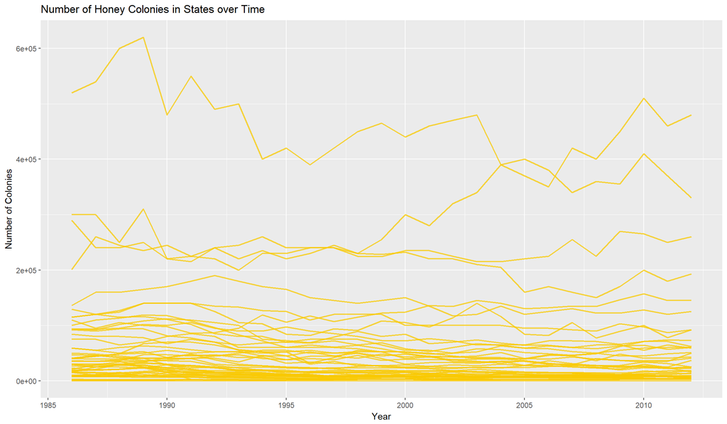

```r
masterhoneydf %>%
  ggplot(aes(x=year,y=numcolonies,group=factor(state))) +
  # color is a particular hex value for "honey" I found online
  geom_line(color="#f9c901", alpha=3/4, size=3/4) +
  labs(title="Number of Honey Colonies in States over Time",
          x="Year", y="Number of Colonies")
```

### Honey Production over Time

This chart in the same format shows the change in production over time

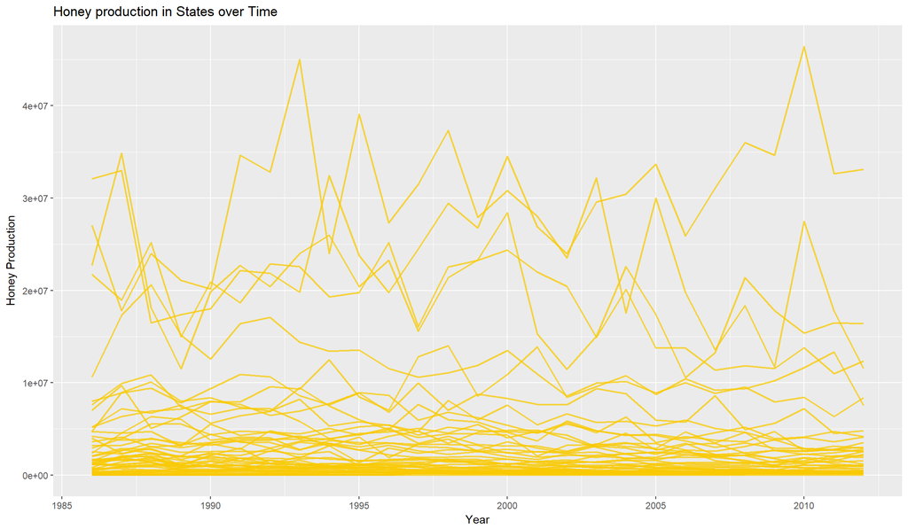

```r
masterhoneydf %>%
  ggplot(aes(x=year,y=production,group=factor(state))) +
  # color is a particular hex value for "honey" I found online
  geom_line(color="#f9c901", alpha=3/4, size=3/4) +
  labs(title="Honey production in States over Time",
          x="Year", y="Honey Production")
```

Honey production does not seem to follow the number of colonies as closely as I thought. This is probably indicative of me not knowing enough about honey prodcution to understand why. Just one example of insights you can get when you visualize the data.

### Number of Honey Colonies in Each State

To show this, I will average the number of colonies for each state over time and then display the numbers on a bar plot. This will show which states have the most bee colonies as well as the distibution of bee colonies over the fifty states. **Bar Plot**

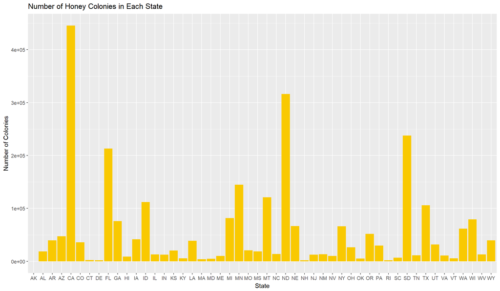

```r
masterhoneydf %>%
  group_by(state) %>%
  summarize(avg = mean(numcolonies)) %>%
  arrange(avg) %>%
  ggplot(aes(x=state,y=avg)) +
  geom_bar(stat="identity",fill="#f9c901") +
  labs(title="Number of Honey Colonies in Each State",
          x="State", y="Number of Colonies")
```

This chart does not look very nice as the values are not in order. lets revise the r code to show the values in order using `reorder` on the `x` parameter in the `aes` function call. **Bar Plot Revised**

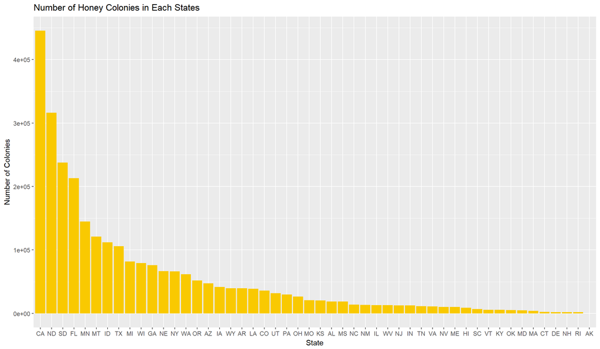

```r
masterhoneydf %>%
  group_by(state) %>%
  summarize(avg_numcol = mean(numcolonies)) %>%
  ggplot(aes(x=reorder(state,-avg_numcol),y=avg_numcol)) +
  geom_bar(stat="identity",fill="#f9c901") +
  labs(title="Number of Honey Colonies in Each States ",
          x="State", y="Number of Colonies")
```

Much nicer but we can do more. Since we have State data we can show the data geographically with some help from some nice R packages.

### Plotting Data Geographically

There is a conveient R package that provides an easy way to do this. It is `fiftystater`. It has a map object that can be passed into `geom_map` and so long as you provide a `map_id` connecting each peice of data with a particular state then ggplot can make a nice looking map like the one below.

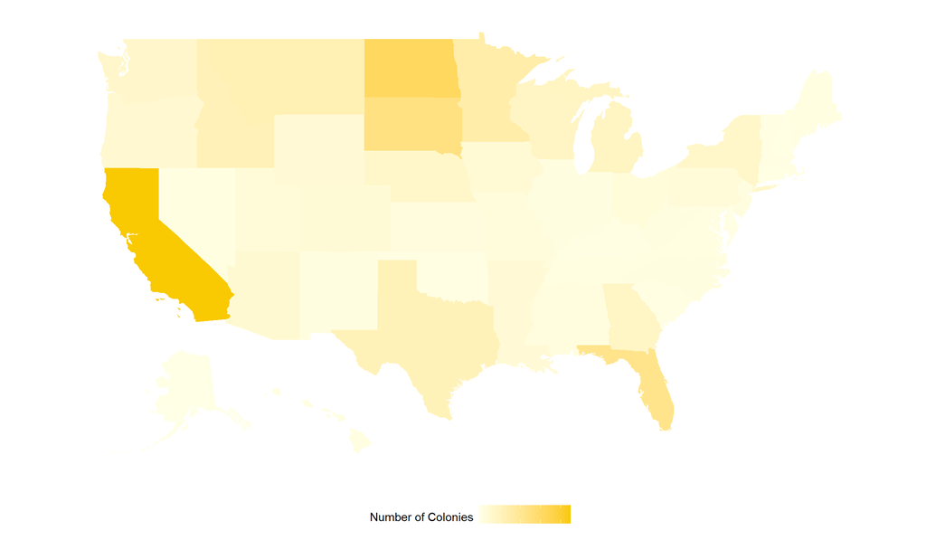

```r
library(fiftystater)

# summarizing the honyey data frame
masterhoneydf %>%
  group_by(state) %>%
  summarize(avg_numcol = mean(numcolonies)) %>%
  # making the call to ggplot
  ggplot(aes(map_id = str_to_lower(abbr_to_name[state]))) +
  geom_map(aes(fill = avg_numcol), map = fifty_states) +
  expand_limits(x = fifty_states$long, y = fifty_states$lat) +
  # insert a honey colored gradient
  scale_fill_gradient(low="#ffffe5", high= "#f9c901", guide = "colorbar", name = "Number of Colonies",labels = NULL) +
  coord_map() +
  # lines below are there to make the map look even nicer
  scale_x_continuous(breaks = NULL) +
  scale_y_continuous(breaks = NULL) +
  labs(x = "", y = "") + # removes labels
  theme(legend.position = "bottom",
        panel.background = element_blank()) #removes background panel
```

When looking at charts in our data we should be looking for interesting insights as well as any problems we can see. Ideally we should be thinking about questions such as:  
what do these plots show us?  
Are there any peculiarites in the data that we need to address?  
Are there any interesting insights that may have been discovered?

From the charts we can see that Califournia is the honey production powerhouse of the United States. More importantly if we looked the number of honey colonies over time we can see a decline in the number of colonies. This is most likely casued by [Colony Collapse Disorder](https://en.wikipedia.org/wiki/Colony_collapse_disorder) Which is one of problems that prompted me to explore this data.

## Machine Learning

In this section I will show how to create a prediction model with the given data. Particularly, the model will predict the whether the change of number of colonies will go up or down. In this paritcular example we will try to predict the change in number of colonies in 2012 using all the data prior to 2012 (1986-2011). In order to do this we will need to create a data frame that has the result we are looking for.

### Setup: Creting the Target Outcome

This new outcome dataframe needs to only have the state and the result (up or down) of the change in the number of colonies from 2011 to 2012.

```r
outcome_honey_df <- masterhoneydf %>%
  # limit to 2011,2012 data
  filter(year %in% c("2011", "2012")) %>%
  select(state, year, numcolonies) %>%
  # need new colomns for each years value
  spread(year, numcolonies) %>%
  # then we can subtract them to get the result
  mutate(diff = `2011` - `2012`) %>%
  # encode the result as either 'up' or 'down'
  mutate(Direction = ifelse(diff>0, "up", "down")) %>%
  # drop the other columns
  select(state, Direction)
```

|  | state | Direction |
| --- | --- | --- |
| 1 | AK | down |
| 2 | AL | up |
| 3 | AR | down |
| 4 | AZ | up |
| 5 | CA | up |
| 6 | CO | up |
| 7 | CT | down |
| 8 | DE | down |
| 9 | FL | down |
| 10 | GA | up |

[output cut: 40 more lines]

### Setup: Adjusting our Data Frame

In order to make the model we will need to change our `masterhoneydf` such that each row corresponds to a state and each columns coresponds to a value of the number of colnoies for that year. We are essentially widening our data frame and as such I will call the new data fram `widedf`. Also I exclude 2012 data because do not want to include the 2012 data in the data frame we will use to make the model.

```r
wide_honey_df <- masterhoneydf %>%
  filter(year <= 2011) %>%
  select(state, year, numcolonies) %>%
  spread(year, numcolonies)
```

|  | state | 1986 | 1987 | 1988 | 1989 | 1990 | 1991 | 1992 | 1993 | 1994 | 1995 | 1996 | 1997 | 1998 | 1999 | 2000 | 2001 | 2002 | 2003 | 2004 | 2005 | 2006 | 2007 | 2008 | 2009 | 2010 | 2011 |
| --- | --- | --- | --- | --- | --- | --- | --- | --- | --- | --- | --- | --- | --- | --- | --- | --- | --- | --- | --- | --- | --- | --- | --- | --- | --- | --- | --- |
| 1 | AK | 0 | 0 | 0 | 0 | 0 | 0 | 0 | 0 | 0 | 0 | 0 | 0 | 0 | 0 | 0 | 0 | 0 | 0 | 0 | 0 | 0 | 0 | 0 | 0 | 0 | 0 |
| 2 | AL | 41000 | 46000 | 42000 | 41000 | 29000 | 23000 | 25000 | 19000 | 18000 | 16000 | 15000 | 14000 | 16000 | 17000 | 16000 | 14000 | 12000 | 13000 | 12000 | 13000 | 11000 | 11000 | 9000 | 9000 | 9000 | 9000 |
| 3 | AR | 21000 | 29000 | 34000 | 34000 | 42000 | 47000 | 45000 | 50000 | 55000 | 55000 | 50000 | 50000 | 53000 | 52000 | 52000 | 50000 | 45000 | 40000 | 40000 | 36000 | 32000 | 28000 | 28000 | 24000 | 25000 | 22000 |
| 4 | AZ | 84000 | 80000 | 80000 | 78000 | 67000 | 75000 | 70000 | 55000 | 53000 | 52000 | 32000 | 42000 | 55000 | 52000 | 40000 | 43000 | 38000 | 35000 | 32000 | 36000 | 30000 | 30000 | 25000 | 20000 | 24000 | 23000 |
| 5 | CA | 520000 | 540000 | 600000 | 620000 | 480000 | 550000 | 490000 | 500000 | 400000 | 420000 | 390000 | 420000 | 450000 | 465000 | 440000 | 460000 | 470000 | 480000 | 390000 | 400000 | 380000 | 340000 | 360000 | 355000 | 410000 | 370000 |
| 6 | CO | 41000 | 44000 | 48000 | 50000 | 55000 | 50000 | 52000 | 53000 | 45000 | 45000 | 30000 | 35000 | 27000 | 27000 | 29000 | 26000 | 24000 | 24000 | 23000 | 28000 | 36000 | 31000 | 27000 | 28000 | 34000 | 31000 |
| 7 | CT | 3000 | 2000 | 2000 | 2000 | 2000 | 2400 | 1800 | 1800 | 1200 | 1600 | 1400 | 2333 | 2667 | 2500 | 3000 | 1600 | 1800 | 1600 | 1875 | 1875 | 2000 | 1875 | 2000 | 2889 | 2889 | 2778 |
| 8 | DE | 1000 | 1000 | 1000 | 1000 | 1000 | 2400 | 1800 | 1800 | 1200 | 1600 | 1400 | 2333 | 2667 | 2500 | 3000 | 1600 | 1800 | 1600 | 1875 | 1875 | 2000 | 1875 | 2000 | 2889 | 2889 | 2778 |
| 9 | FL | 290000 | 240000 | 240000 | 250000 | 220000 | 225000 | 220000 | 200000 | 230000 | 230000 | 240000 | 240000 | 230000 | 228000 | 232000 | 220000 | 220000 | 210000 | 205000 | 160000 | 170000 | 160000 | 150000 | 170000 | 200000 | 180000 |
| 10 | GA | 115000 | 120000 | 115000 | 116000 | 111000 | 102000 | 85000 | 80000 | 80000 | 70000 | 75000 | 75000 | 75000 | 65000 | 55000 | 55000 | 50000 | 52000 | 63000 | 59000 | 63000 | 60000 | 65000 | 65000 | 55000 | 65000 |

[output cut: 40 more lines]

### Creating the Model

In order to create the model we need to combine the outcome dataframe and the widened data frame so that the model can have a variable to predict one. once this is down we can go ahead and make the model.

```r
library(randomForest)

final_honey_df <- wide_honey_df %>%
  inner_join(outcome_honey_df, by="state") %>%
  mutate(Direction=factor(Direction, levels=c("down", "up"))) %>%
  data.frame() # neede to fix columns names that make randomForest unhappy

# now we can make the random forest

rf_honey <- randomForest(Direction~., data=final_honey_df %>% select(-state))
rf_honey
```

```
##
## Call:
##  randomForest(formula = Direction ~ ., data = final_honey_df %>%      select(-state))
##                Type of random forest: classification
##                      Number of trees: 500
## No. of variables tried at each split: 5
##
##         OOB estimate of  error rate: 34%
## Confusion matrix:
##      down up class.error
## down   31  6   0.1621622
## up     11  2   0.8461538
```

## Conclusion

We learned how to scrape data from text files, how to handle missing data. We saw how to make graphs that can intuitively show the data and how attributes relate to one another. We were also able to make a map that that can show the data geographically which is not always possible in some datasets.

Additionally, we laid the foundataion for creating and testing a prediction model based on random forest.

I hoped you liked the tuturial.